# Week 5 Discussion

Michelle Vered

2023-02-05

# Code

```
##   Attrition          Department          JobRole            HourlyRate
##  Length:1676        Length:1676        Length:1676        Min.   : 30.00
##  Class :character   Class :character   Class :character   1st Qu.: 48.00
##  Mode  :character   Mode  :character   Mode  :character   Median : 65.50
##                                                           Mean   : 65.47
##                                                           3rd Qu.: 83.00
##                                                           Max.   :100.00
##  PerformanceRating
##  Min.   :3.00
##  1st Qu.:3.00
##  Median :3.00
##  Mean   :3.15
##  3rd Qu.:3.00
##  Max.   :4.00
```

```
##
##   No  Yes
## 1477  199
```

```
##
## Cardiology  Maternity  Neurology
##        531        796        349
```

```
##
## Administrative          Nurse          Other      Therapist
##            131            822            534            189
```

# Analysis

## Links

Github Link: https://github.com/mvered/DMA3300/tree/main/week_5

Data Source Link: https://www.kaggle.com/datasets/jpmiller/employee-attrition-for-healthcare/versions/2?resource=download

## Background on Data Set

This data set includes information on employees of a hospital system, including their work history, hourly wage rates, job role, job satisfaction, performance rating, whether or not they are a current employee or have left, and more. The data is synthetic data, but based on real information. It comes from an IBM Watson data set. The data set was created and uploaded in 2022.

## Research Question & Motivation

We’re interested in understanding how wages differ across job roles, how much the hospital system is paying on average per employee per year, and how much in total the hospital is spending on employee wages per year. We can also simulate a scenario in which employees with high performance ratings are given a 3% raise, and see how much that affects the total spend on wages per year. This is the type of information that the HR department and management at a hospital system would be interested in understanding about its employees.

## Data Description & Descriptive Statistics

The data set includes a long list of columns related to hospital employees. In this analysis, we’ll focus on a subset of those columns. The important columns to keep in mind are:

- **Attrition:** Whether an employee has left the hospital or not (“no” indicates they are a current employee, “yes” indicates they have left). There are 1,477 current employees and 199 who have left in this data set.
- **Department:** What unit of the hospital the employee is in. There are 531 cardiology employees, 796 in maternity, and 349 in Neurology.
- **JobRole:** What position the employee holds. After combining the “Admin” and “Administrative” categories, there are:
  - 131 Administrative employees
  - 822 Nurses
  - 189 Therapists
  - 534 Other employees
- **HourlyRate:** The hourly wage each employee is paid. The average is $65.47 per hour, with a minimum of $30 per hour and a maximum of $100 per hour.
- **PerformanceRating:** The employee’s most recent performance rating. In this data set all employees were rated either 3 or 4, with the average being 3.15.

## Data Analysis & Visualizations

On a per employee basis, the hospital is spending an average of $136737.8199052 per year.

Looking at all current employees, the total amount spent in a year on wages is $201,961,760. That’s assuming all employees work 40 hours per week 52 weeks per year (or work 50 weeks per year with 2 weeks paid time off). If the hospital gave a raise to all employees with a higher performance rating (4 or above), the total amount spent on wages in a year would be $202,869,430. That’s an increase in total costs of 0.45 percent.

We can also look at how wages differ across job roles and departments in the hospital. We can see in the attached box plot that wages are relatively similar across departments, with neurology perhaps slightly lower than cardiology and maternity. The second box plot shows that wages are also relatively similar between job roles.

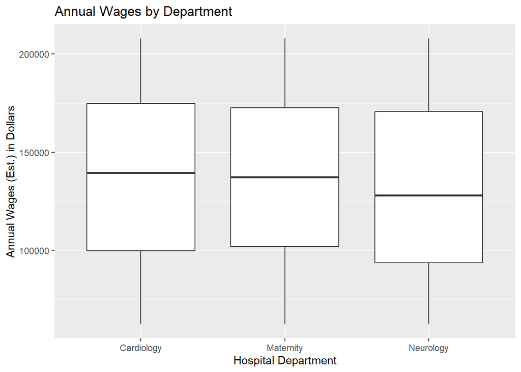

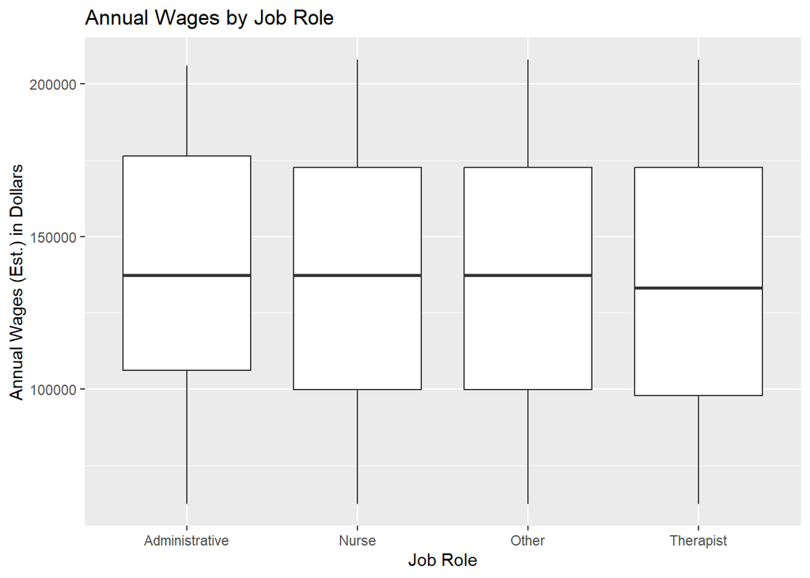

## Findings

1. Raising wages by 3% for employees with a high performance rating would not significantly increase labor costs at the hospital. It would increase estimated annual costs for wages by only 0.45 percent.
2. Wages across hospital departments are similar, with neurology perhaps slightly lower than cardiology and maternity. This is shown in the first box plot.
3. Wages across job roles are very similar, as shown in the second box plot.